# Improving Plot Aesthetics

Generate a line chart that visualizes the historical percentage of Biology degrees awarded to women: Set the x-axis to the Year column from women_degrees. Set the y-axis to the Biology column from women_degrees. Display the plot.

```python
import pandas as pd
import matplotlib.pyplot as plt
%matplotlib inline

women_degrees = pd.read_csv('percent-bachelors-degrees-women-usa.csv')
```

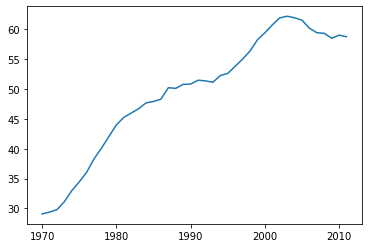

```python
plt.plot(women_degrees['Year'],women_degrees['Biology'])

plt.show()
```

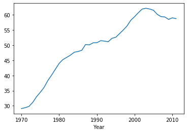

```python
women_degrees.plot.line(x = 'Year', y = 'Biology', legend = False)

#SUBPLOT and AXES inside
```

From the plot, we can tell that Biology degrees increased steadily from 1970 and peaked in the early 2000's. We can also tell that the percentage has stayed above 50% since around 1987. While it's helpful to visualize the trend of Biology degrees awarded to women, it only tells half the story. If we want the gender gap to be apparent and emphasized in the plot, we need a visual analogy to the difference in the percentages between the genders.

If we visualize the trend of Biology degrees awarded to men on the same plot, a viewer can observe the space between the lines for each gender. We can calculate the percentages of Biology degrees awarded to men by subtracting each value in the Biology column from 100. Once we have the male percentages, we can generate two line charts as part of the same diagram.

Let's now create a diagram containing both the line charts we just described.

Generate 2 line charts on the same figure: One that visualizes the percentages of Biology degrees awarded to women over time. Set the line color to "blue" and the label to "Women". One that visualizes the percentages of Biology degrees awarded to men over time. Set the line color to "green" and the label to "Men". Set the title of the chart to "Percentage of Biology Degrees Awarded By Gender". Generate a legend and place it in the "upper right" location. Display the chart.

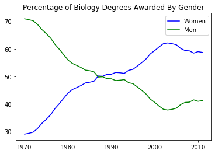

```python
plt.plot(women_degrees['Year'],women_degrees['Biology'], c = 'blue', label = 'Women')
plt.plot(women_degrees['Year'],100 -women_degrees['Biology'], c = 'green', label = 'Men')
plt.title('Percentage of Biology Degrees Awarded By Gender')
plt.legend(loc = 'upper right')

plt.show()
```

To customize the appearance of the ticks, we use the Axes.tick_params() method. Using this method, we can modify which tick marks and tick labels are displayed. By default, matplotlib displays the tick marks on all four sides of the plot. Here are the four sides for a standard line chart:

The left side is the y-axis. The bottom side is the x-axis. The top side is across from the x-axis. The right side is across from the y-axis.

Generate 2 line charts in the same plotting area: One that visualizes the percentages of Biology degrees awarded to women over time. Set the line color to "blue" and the label to "Women". One that visualizes the percentages of Biology degrees awarded to men over time. Set the line color to "green" and the label to "Men". Remove all of the tick marks. Set the title of the plot to "Percentage of Biology Degrees Awarded By Gender". Generate a legend and place it in the "upper right" location. Display the chart.

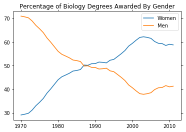

```python
fig, ax = plt.subplots()

ax.plot(women_degrees['Year'], women_degrees['Biology'], label = 'Women')
ax.plot(women_degrees['Year'], 100 - women_degrees['Biology'], label = 'Men')

ax.tick_params(bottom = 'off', top = 'off', right = 'off', left = 'off')
ax.set_title('Percentage of Biology Degrees Awarded By Gender')
ax.legend(loc = 'upper right')

plt.show()
```

In matplotlib, the spines are represented using the matplotlib.spines.Spine class. When we create an Axes instance, four Spine objects are created for us. If you run print(ax.spines), you'll get back a dictionary of the Spine objects:

```python
print(ax.spines)
#key-value pairs
```

```
OrderedDict([('left', <matplotlib.spines.Spine object at 0x0000028B40D5D408>), ('right', <matplotlib.spines.Spine object at 0x0000028B40D5D548>), ('bottom', <matplotlib.spines.Spine object at 0x0000028B40D5D2C8>), ('top', <matplotlib.spines.Spine object at 0x0000028B40D5D7C8>)])
```

To hide all of the spines, we need to:

access each Spine object in the dictionary call the Spine.set_visible() method pass in the Boolean value False

The following line of code removes the spines for the right axis:

```python
ax.spines["right"].set_visible(False)
```

Generate 2 line charts on the same plotting area: One that visualizes the percentages of Biology degrees awarded to women over time. Set the line color to "blue" and the label to "Women". One that visualizes the percentages of Biology degrees awarded to men over time. Set the line color to "green" and the label to "Men". Remove all of the axis tick marks. Hide all of the spines. Set the title of the plot to "Percentage of Biology Degrees Awarded By Gender". Generate a legend and place it in the "upper right" location. Display the chart.

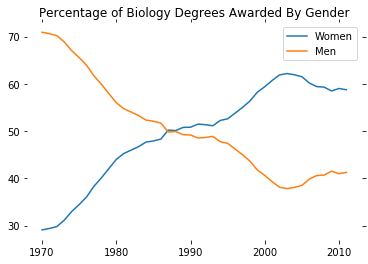

```python
fig, ax = plt.subplots()

ax.plot(women_degrees['Year'], women_degrees['Biology'], label = 'Women')
ax.plot(women_degrees['Year'], 100 - women_degrees['Biology'], label = 'Men')
ax.tick_params(bottom = 'off', top = 'off', right = 'off', left = 'off')

#add code here
for key,spine in ax.spines.items():
    spine.set_visible(False)

ax.set_title('Percentage of Biology Degrees Awarded By Gender')
ax.legend(loc = 'upper right')

plt.show()
```

So far, **matplotlib has set the limits automatically for each axis** and this hasn't had any negative effect on communicating our story with data. If we want to generate charts to compare multiple degree categories, the axis ranges need to be consistent. Inconsistent data ranges can distort the story our charts are telling and fool the viewer.

Edward Tufte often preaches that a good chart encourages comparison over just description. A good chart uses a consistent style for the elements that aren't directly conveying the data points. These elements are part of the non-data ink in the chart. By keeping the non-data ink as consistent as possible across multiple plots, differences in those elements stick out easily to the viewer. This is because our visual processing systems are excellent at discerning differences quickly and brings them to the front of our thought process. The similarities naturally fade to the back of our thought process.

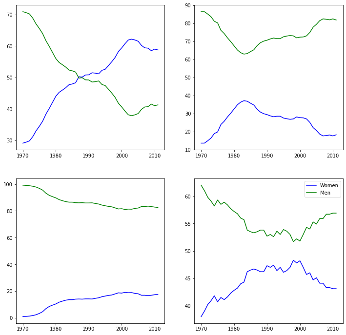

```python
major_cats = ['Biology', 'Computer Science', 'Engineering', 'Math and Statistics']
fig = plt.figure(figsize=(12, 12))

for sp in range(0,4):
    ax = fig.add_subplot(2,2,sp+1)
    ax.plot(women_degrees['Year'], women_degrees[major_cats[sp]], c='blue', label='Women')
    ax.plot(women_degrees['Year'], 100-women_degrees[major_cats[sp]], c='green', label='Men')
    # Add your code here.

# Calling pyplot.legend() here will add the legend to the last subplot that was created.
plt.legend(loc='upper right')
plt.show()
```

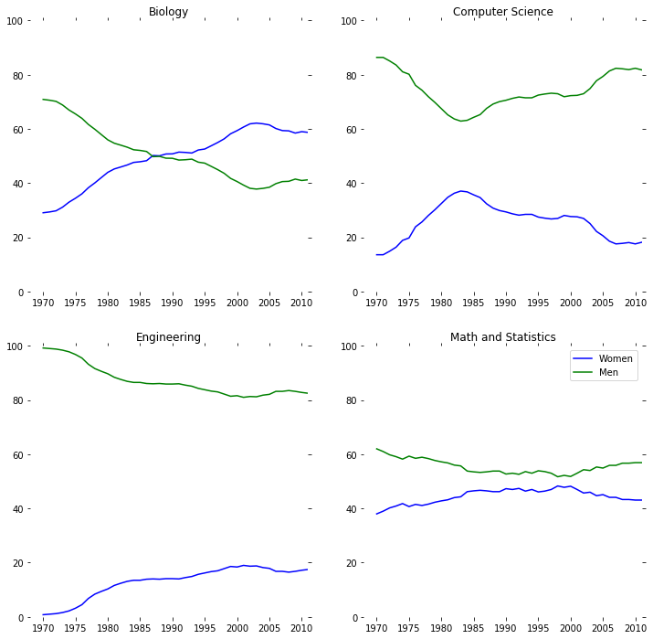

```python
major_cats = ['Biology', 'Computer Science', 'Engineering', 'Math and Statistics']
fig = plt.figure(figsize=(12, 12))

for sp in range(0,4):
    ax = fig.add_subplot(2,2,sp+1)
    ax.plot(women_degrees['Year'], women_degrees[major_cats[sp]], c='blue', label='Women')
    ax.plot(women_degrees['Year'], 100-women_degrees[major_cats[sp]], c='green', label='Men')
    # Add your code here.
    for key, spine in ax.spines.items():
        spine.set_visible(False)
    ax.set_xlim(1968,2011)
    ax.set_ylim(0,100)
    ax.set_title(major_cats[sp])
    ax.tick_params(bottom = 'off', top = 'off', left = 'off', right = 'off')


# Calling pyplot.legend() here will add the legend to the last subplot that was created.
plt.legend(loc='upper right')
plt.show()
```